# IE360 HW3 SÜLEYMAN TURANCAN BURUCU

Süleyman Turancan Burucu

12/14/2020

# A Study About the Relation Among USD/TRY Exchange Rates, Foreign Debt Amount (in million USD) and Residential Property Price Index (RPPI)

## **1. Introduction**

These topics are chosen exceptionally. Why I chosen these topics can be explained by Republic of Turkey’s debts are generally foreign debts, i.e. borrowed in foreign currency, and this condition have been affected and have affected another economical values. To clarify, Turkish government have continued to borrow USD as a debt for as long as I’ve known. Also, USD against Turkish Lira exchange rate (USD/TL) is the foremost factor determining the residential prices due to the prices of iron are determined in USD globally, not in Turkish Lira (TL). Furthermore, residential properties are constructed with local materials alongwith imported materials in considerable amount. Therefore, USD/TL rate affects the foreign debt amount and RPPI.

Besides, borrowing more foreign debts in USD ends up again increasing value of USD against TL. Accordingly, there is at least one vicious circle among these topics. Therefore, it can be asserted that USD/TL exchange rate affects foreign debt amount and RPPI. Yet, how much are we sure about their relationships? Can we say that the same condition holds for vice versa? If we want to reach a conclusion, we need to examine our data visually and statistically, i.e. mathematically. Therefore, I’m going to start with showing the histogram of our data. foreign debt amount, and RPPI are shown below, respectively:

> Yet, it should be kept in mind that we have been analysing only for a period, just 7 years. Therefore, we can definitely say that our calculations and results are not immutable. So, someone with different data can reach another conclusion. Also, I can reach another conclusion with another data. Therefore, conclusions below are valid only for 7 year term.

## **2. Tables and Their Explanations**

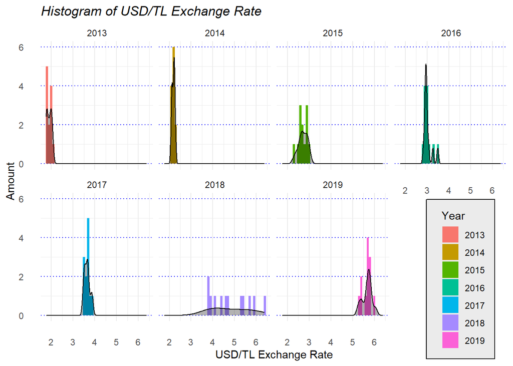

It can be easily seen that how the bars have moved through the end of the x-axis, meaning that that from 2013 to 2020 USD/TL has increased, in general. Also, we can say that the 2018 is the year that this rate has fluctuated in large interval a lot owing to the results of degraded economical policies. Also, this condition brang forth price increases. For example, e-commerce sites have updated their imported goods’ prices hourly, also some car dealer have stopped their sales until a further notice. Let’s continue with another table:

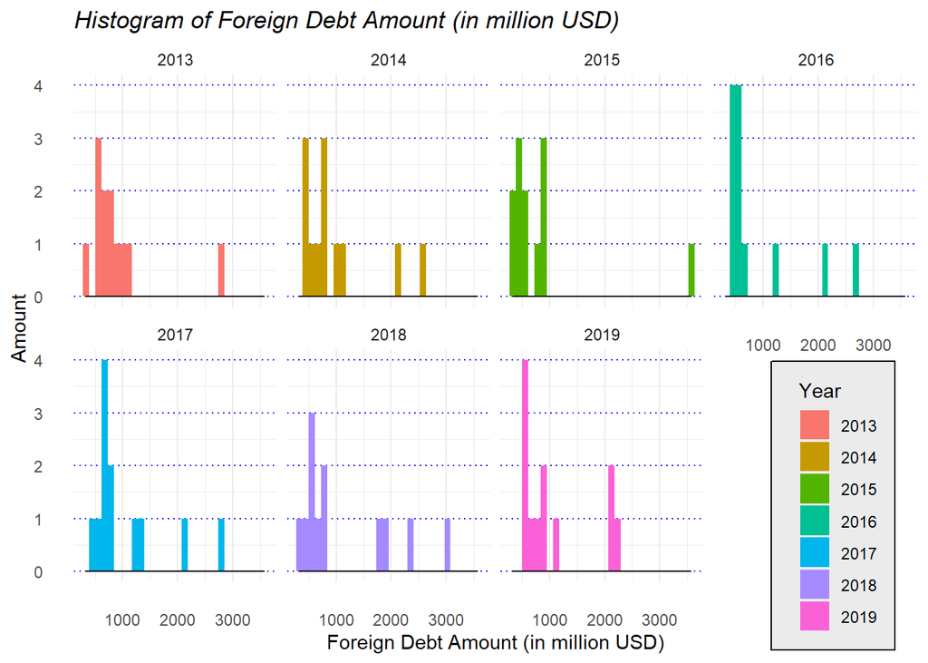

As I mentioned, Turkish government has been borrowing foreign debts for many years. Yet, bear in mind that all debts are not taken in USD, there is also another types of foreign currency Turkey have taken. Other than that, this histogram is somewhat different from the USD/TL’s histogram, since it can be seen that graph above has internal consistency for each year, i.e. years are more similar to each other rather than the USD/TL plot, just because the USD graph is increasing somewhat continuously as we can see. Let’s continue with another table:

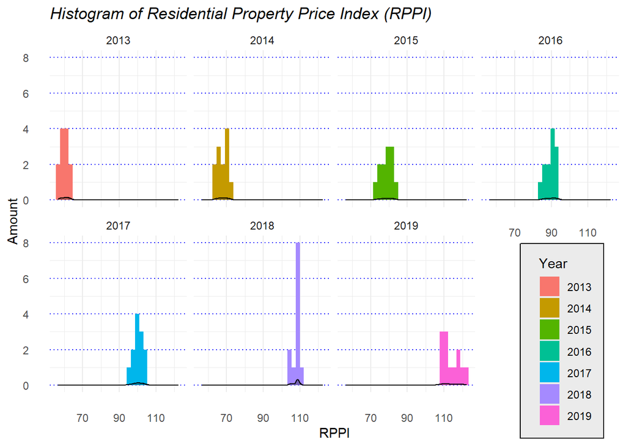

Lastly, we can see that the RPPI values have increased like USD/TL did, as it were the USD/TL and RPPI have traced a trend, i.e. increased more stable and alike, not like foreign debt histogram. Let’s make it more clear by looking at these 3 graphs’ values in one table and what I am mentioning by saying “alike”:

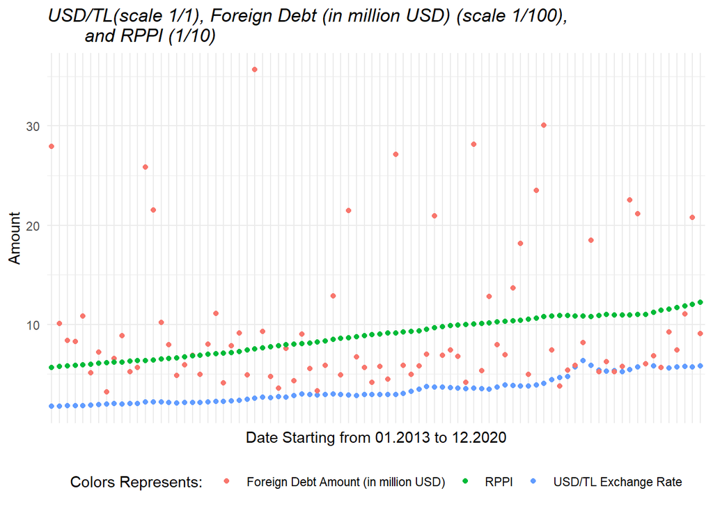

>This graph is drawn by dividing Foreign Debt (in million USD) by 100 and RPPI by 10 and no change in the USD/TL Exchange Rate.

You can easily determine that, USD/TL and RPPI values are like tracing an increasing path, which is what I trying to clarify by saying “alike” and “stable”. To be more exact, we need to check the correlation between USD/TL exchange rate, foreign debt, and RPPI values. Therefore, let’s look at their corelogram, a table which shows the correlations of each data one-by-one:

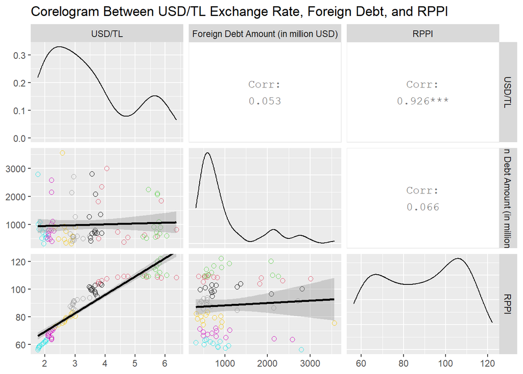

From that table, we can see and mathematically conclude that USD/TL and RPPI has considerably related. Predictably, we have said that USD/TL and RPPI are “stable” and “alike”. At this phase, I have clarified and showed what “alikeness” is and how it can be seen by corelogram. Yet, we have said that there can be another relationship between each other,but when we look at the correlation coefficients of the each relationship, we can say that the only considerable relation is between USD/TL and RPPI, there is no relation between foreign debt vs. USD/TL, or foreign debt vs. RPPI. This condition can be explained by foreign debts are not only borrowed in USD and this situation makes the foreign debt values trace different route from USD/TL or RPPI follow.

If we want to check the correlations for each year, we can make another corelogram for each year whether correlation exists between USD/TL, foreign debts, and RPPI. As a reminder, we have been looking for 12 data for each year and it doesn’t give the supreme and immutable relationship between them, just mathematical calculations give these results for the data sets we have:

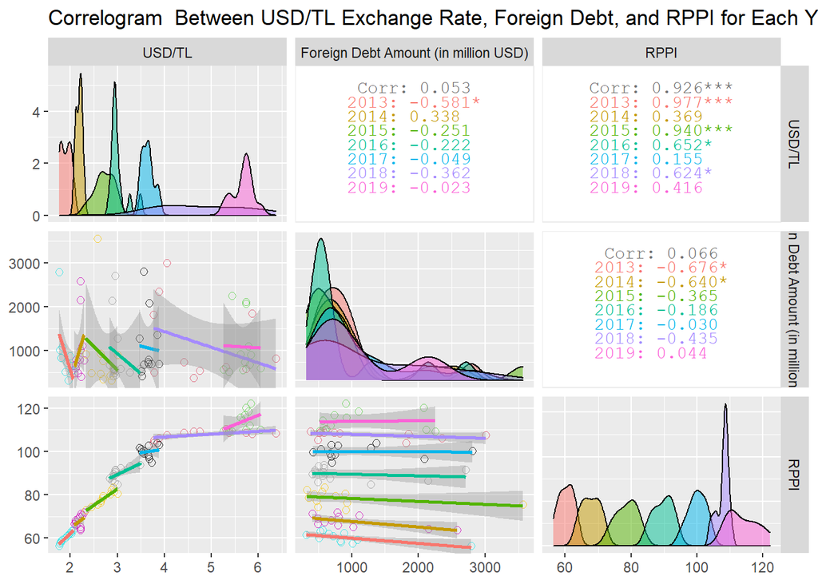

Here we can observe that the USD/TL and RPPI are positively correlated especially for 2013 and 2015 and positively correlated in general. As I said, we can examine our data in various aspects and find different results. Also, even we find unimportant correlation coefficients among foreign debt - RPPI and foreign debt - USD/TL, in some of the years our program has caught some correlation but not so important. Presumably, this condition results from having only 12 data for each year, and the correlation might not be found if we examined the each year by lookin their daily values. Yet, some of the values are not calculated in a daily basis, unfortunately.

If we want to see the results of Pearson’s product-moment correlation, which is same with what we have found, showing the correlations between USD/TL exchange rate, foreign debt and RPPI more formally.

Here, the results for the correlation between USD/TL exchange rate and foreign debt:

```
##
##  Pearson's product-moment correlation
##
## data:  exc and debt
## t = 0.48455, df = 82, p-value = 0.6293
## alternative hypothesis: true correlation is not equal to 0
## 95 percent confidence interval:
##  -0.1628279  0.2647944
## sample estimates:
##        cor
## 0.05343262
```

Here, the results for the correlation between USD/TL exchange rate and RPPI is shown:

```
##
##  Pearson's product-moment correlation
##
## data:  exc and ykfe
## t = 22.216, df = 82, p-value < 2.2e-16
## alternative hypothesis: true correlation is not equal to 0
## 95 percent confidence interval:
##  0.8879147 0.9515129
## sample estimates:
##       cor
## 0.9260271
```

Here, the results for the correlation between foreign debt and RPPI is shown:

```
##
##  Pearson's product-moment correlation
##
## data:  debt and ykfe
## t = 0.5949, df = 82, p-value = 0.5536
## alternative hypothesis: true correlation is not equal to 0
## 95 percent confidence interval:
##  -0.1509628  0.2760693
## sample estimates:
##       cor
## 0.0655541
```

## **4. Resources**

- [EVDS](https://evds2.tcmb.gov.tr/index.php?/evds/serieMarket/collapse_2/5868/DataGroup/turkish/bie_rktufey/)
- [Stackoverflow](https://stackoverflow.com/)
- [A Brief Introduction to ggpairs()](https://www.blopig.com/blog/2019/06/a-brief-introduction-to-ggpairs/)
- [tidyverse.org](https://ggplot2.tidyverse.org/)
- [statmethods.net](https://www.statmethods.net/)
- [RStudio Community](https://community.rstudio.com/)
- [r-graph-gallery.com](https://www.r-graph-gallery.com/)
- [Datacamp](https://www.datacamp.com/)